# Lab 8

### Repository Link

You can view the full project repository on [Github](https://github.com/DanielPelerman/GSB-544-Git/tree/main/Week%209/Lab%208)

### Part 0: Data Cleaning and Summary

```python
import pandas as pd
from IPython.display import HTML, display

url = "https://www.dropbox.com/s/s2a1uoiegitupjc/cannabis_full.csv?dl=1"
df = pd.read_csv(url)

display(HTML("<b>Data Preview:</b>"))
print(df.head())

display(HTML("<b>Data types:</b>"))
print(df.dtypes)

display(HTML("<b>Missing values per column:</b>"))
print(df.isna().sum())

display(HTML("<b>Dataset shape (rows, columns):</b>"))
print(df.shape)

display(HTML("<b>Non-missing values per column:</b>"))
print(df.count())
```

**Data Preview:**

```
           Strain    Type  Rating                                     Effects  \
0          100-Og  hybrid     4.0  Creative,Energetic,Tingly,Euphoric,Relaxed
1  98-White-Widow  hybrid     4.7    Relaxed,Aroused,Creative,Happy,Energetic
2            1024  sativa     4.4   Uplifted,Happy,Relaxed,Energetic,Creative
3        13-Dawgs  hybrid     4.2     Tingly,Creative,Hungry,Relaxed,Uplifted
4        24K-Gold  hybrid     4.6   Happy,Relaxed,Euphoric,Uplifted,Talkative

                      Flavor  Creative  Energetic  Tingly  Euphoric  Relaxed  \
0        Earthy,Sweet,Citrus       1.0        1.0     1.0       1.0      1.0
1      Flowery,Violet,Diesel       1.0        1.0     0.0       0.0      1.0
2    Spicy/Herbal,Sage,Woody       1.0        1.0     0.0       0.0      1.0
3  Apricot,Citrus,Grapefruit       1.0        0.0     1.0       0.0      1.0
4       Citrus,Earthy,Orange       0.0        0.0     0.0       1.0      1.0

   ...  Ammonia  Minty  Tree  Fruit  Butter  Pineapple  Tar  Rose  Plum  Pear
0  ...      0.0    0.0   0.0    0.0     0.0        0.0  0.0   0.0   0.0   0.0
1  ...      0.0    0.0   0.0    0.0     0.0        0.0  0.0   0.0   0.0   0.0
2  ...      0.0    0.0   0.0    0.0     0.0        0.0  0.0   0.0   0.0   0.0
3  ...      0.0    0.0   0.0    0.0     0.0        0.0  0.0   0.0   0.0   0.0
4  ...      0.0    0.0   0.0    0.0     0.0        0.0  0.0   0.0   0.0   0.0

[5 rows x 69 columns]
```

**Data types:**

```
Strain        object
Type          object
Rating       float64
Effects       object
Flavor        object
              ...
Pineapple    float64
Tar          float64
Rose         float64
Plum         float64
Pear         float64
Length: 69, dtype: object
```

**Missing values per column:**

```
Strain         0
Type           0
Rating         0
Effects       87
Flavor       156
            ...
Pineapple     46
Tar           46
Rose          46
Plum          46
Pear          46
Length: 69, dtype: int64
```

**Dataset shape (rows, columns):**

```
(2351, 69)
```

**Non-missing values per column:**

```
Strain       2351
Type         2351
Rating       2351
Effects      2264
Flavor       2195
             ...
Pineapple    2305
Tar          2305
Rose         2305
Plum         2305
Pear         2305
Length: 69, dtype: int64
```

**Data Summary:**  
The dataset includes 2,351 cannabis strains and 69 different variables describing things like each strain’s type, rating, reported effects, and flavor notes. Core columns such as Strain, Type, and Rating are fully complete, while the text-based fields Effects and Flavor have some missing entries (87 and 156, respectively). The remaining 60+ columns are one-hot encoded indicators showing whether a specific effect or flavor is present. These also include a small amount of missing data (usually around 46 rows per column). Overall, the dataset mixes categorical information, numerical ratings, and a wide set of binary features, giving us a detailed foundation for exploring and building classification models.

### Part 1: Binary Classification

```python
# Start from the filtered dataset
df_binary = df[df["Type"].isin(["sativa", "indica"])].copy()

# Drop string columns (we won't use these)
df_binary = df_binary.drop(columns=["Strain", "Effects", "Flavor"])

# Convert target to binary
df_binary["Type_binary"] = (df_binary["Type"] == "indica").astype(int)

# Drop original Type column
df_binary = df_binary.drop(columns=["Type"])

df_binary = df_binary.dropna()

X = df_binary.drop(columns=["Type_binary"])
y = df_binary["Type_binary"]

print("New dataset shape:", df_binary.shape)

display(HTML("<b>Count of indica vs sativa after cleaning:</b> (Indica = 1, Sativa = 0)"))
print(df_binary["Type_binary"].value_counts())
```

```
New dataset shape: (1118, 66)
```

**Count of indica vs sativa after cleaning:** (Indica = 1, Sativa = 0)

```
Type_binary
1    687
0    431
Name: count, dtype: int64
```

```python
from sklearn.model_selection import cross_val_score
from sklearn.discriminant_analysis import LinearDiscriminantAnalysis
from sklearn.metrics import confusion_matrix
from IPython.display import HTML, display
import warnings

warnings.filterwarnings("ignore", category=RuntimeWarning)

# Create model
lda = LinearDiscriminantAnalysis()

# Cross-validated accuracy
cv_scores = cross_val_score(lda, X, y, cv=5, scoring="accuracy")

display(HTML("<b>LDA Cross-validated accuracy:</b>"))
print("Mean CV accuracy:", round(cv_scores.mean(), 4))

# Fit final model on entire dataset
lda_final = LinearDiscriminantAnalysis().fit(X, y)

# Predictions + confusion matrix
preds = lda_final.predict(X)

display(HTML("<b>LDA Confusion matrix:</b>"))
print(confusion_matrix(y, preds))
```

**LDA Cross-validated accuracy:**

```
Mean CV accuracy: 0.8426
```

**LDA Confusion matrix:**

```
[[345  86]
 [ 60 627]]
```

*LDA does not require hyperparameter tuning in this setting because the version used in class has no tunable arguments. Since all predictors were included for every model, the only step needed was to perform cross-validation directly on the base LDA model and then fit it on the full cleaned dataset. LDA provides a strong baseline linear classifier and performed well overall.*

```python
from sklearn.discriminant_analysis import QuadraticDiscriminantAnalysis
from sklearn.model_selection import GridSearchCV
import warnings

warnings.filterwarnings("ignore", category=RuntimeWarning)

qda = QuadraticDiscriminantAnalysis()

param_grid = {
    "reg_param": [0.0, 0.1, 0.2, 0.3, 0.4, 0.5]
}

qda_search = GridSearchCV(
    qda,
    param_grid=param_grid,
    cv=5,
    scoring="accuracy"
)

qda_search.fit(X, y)

display(HTML("<b>QDA Cross-validated accuracy:</b>"))
print("Best reg_param:", qda_search.best_params_["reg_param"])
print("Mean CV accuracy:", round(qda_search.best_score_, 4))

qda_final = QuadraticDiscriminantAnalysis(
    reg_param=qda_search.best_params_["reg_param"]
).fit(X, y)

# Predictions + confusion matrix
qda_preds = qda_final.predict(X)

display(HTML("<b>QDA Confusion matrix:</b>"))
print(confusion_matrix(y, qda_preds))
```

**QDA Cross-validated accuracy:**

```
Best reg_param: 0.1
Mean CV accuracy: 0.8542
```

**QDA Confusion matrix:**

```
[[368  63]
 [ 63 624]]
```

*QDA includes a shrinkage parameter (reg_param) that can help stabilize covariance estimates when working with high-dimensional data. A small GridSearchCV was used to select the best-performing model. After identifying the best parameter, the final QDA model was fit on the full dataset.*

```python
from sklearn.svm import SVC
from sklearn.preprocessing import StandardScaler
from sklearn.pipeline import Pipeline

warnings.filterwarnings("ignore", category=RuntimeWarning)

svc_pipeline = Pipeline([
    ("scaler", StandardScaler()),
    ("svc", SVC(kernel="rbf"))
])

param_grid = {
    "svc__C": [0.1, 1, 10],
    "svc__gamma": [0.01, 0.1, 1]
}

svc_search = GridSearchCV(
    svc_pipeline,
    param_grid=param_grid,
    cv=5,
    scoring="accuracy"
)

svc_search.fit(X, y)

# cross-validated results
display(HTML("<b>SVC Cross-validated accuracy:</b>"))
print("Best parameters:", svc_search.best_params_)
print("Mean CV accuracy:", round(svc_search.best_score_, 4))

# fit final model
svc_final = svc_search.best_estimator_.fit(X, y)

# confusion matrix
svc_preds = svc_final.predict(X)

display(HTML("<b>SVC Confusion matrix:</b>"))
print(confusion_matrix(y, svc_preds))
```

**SVC Cross-validated accuracy:**

```
Best parameters: {'svc__C': 1, 'svc__gamma': 0.01}
Mean CV accuracy: 0.8364
```

**SVC Confusion matrix:**

```
[[360  71]
 [ 31 656]]
```

*SVC was fit using the RBF kernel, which is the nonlinear SVM model introduced in class. Because SVMs rely on distance-based kernels, all predictors were standardized using a pipeline. Tuning was limited to the key hyperparameters C and gamma, which control model flexibility and smoothness of the decision boundary. The best-performing combination was then used to fit the final model.*

```python
warnings.filterwarnings("ignore", category=RuntimeWarning)

svm_pipeline = Pipeline([
    ("scaler", StandardScaler()),
    ("svm", SVC(kernel="poly"))
])

param_grid = {
    "svm__C": [0.1, 1, 10],
    "svm__degree": [2, 3, 4]
}

svm_search = GridSearchCV(
    svm_pipeline,
    param_grid=param_grid,
    cv=5,
    scoring="accuracy"
)

svm_search.fit(X, y)

# cross-validated accuracy
display(HTML("<b>SVM (Polynomial) Cross-validated accuracy:</b>"))
print("Best parameters:", svm_search.best_params_)
print("Mean CV accuracy:", round(svm_search.best_score_, 4))

# Fit final model using best hyperparameters
svm_final = svm_search.best_estimator_.fit(X, y)

# Predictions + confusion matrix
svm_preds = svm_final.predict(X)

display(HTML("<b>SVM (Polynomial) Confusion matrix:</b>"))
print(confusion_matrix(y, svm_preds))
```

**SVM (Polynomial) Cross-validated accuracy:**

```
Best parameters: {'svm__C': 10, 'svm__degree': 3}
Mean CV accuracy: 0.8301
```

**SVM (Polynomial) Confusion matrix:**

```
[[394  37]
 [  4 683]]
```

*The polynomial SVM model was evaluated separately from SVC, consistent with the lab instructions. Only C and the polynomial degree were tuned, as these are the core hyperparameters discussed in class. A scaling step was included in the pipeline, and the best polynomial SVM was then fit on the full dataset to obtain final predictions.*

**Part 1 Conclusion:**  
Across all four models, overall accuracy served as an appropriate evaluation metric because neither class (indica vs. sativa) was prioritized in the problem definition, and the cleaned dataset remained reasonably balanced. Accuracy therefore provided a fair measure of how well each model separated the two types without weighting one outcome more heavily than the other.

Among the models, QDA achieved the highest cross-validated accuracy (0.8542), suggesting that allowing class-specific covariance structures provided a measurable benefit in this setting. LDA also performed strongly (0.8426), indicating that a linear boundary captures much of the inherent structure in the predictors. The SVM models performed slightly lower overall, with SVC (RBF) at 0.8364 and the polynomial SVM at 0.8301, though both produced confusion matrices with relatively few misclassifications, particularly for the indica class. These results show that while all four methods performed well, QDA provided the best combination of accuracy and predictive stability for distinguishing between indica and sativa strains.

### Part 2: Natural Multiclass

```python
df_multi = df.copy()

df_multi = df_multi.drop(columns=["Strain", "Effects", "Flavor"])
df_multi = df_multi.dropna()

# Encode target into multiclass labels (indica, sativa, hybrid)
df_multi["Type_multi"] = df_multi["Type"].astype("category").cat.codes

X_multi = df_multi.drop(columns=["Type", "Type_multi"])
y_multi = df_multi["Type_multi"]

print("New multiclass dataset shape:", df_multi.shape)
print(df_multi["Type"].value_counts())
```

```
New multiclass dataset shape: (2305, 67)
Type
hybrid    1187
indica     687
sativa     431
Name: count, dtype: int64
```

**Decision Tree Cross-validated accuracy:**

```
Best max_depth: 3
Mean CV accuracy: 0.6217
```

**Decision Tree Confusion matrix:**

```
[[861 189 137]
 [255 422  10]
 [240  20 171]]
```

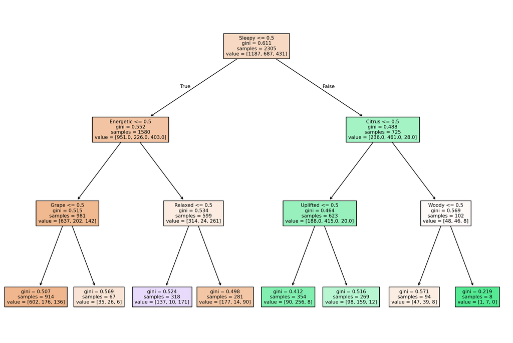

```python
from sklearn.tree import DecisionTreeClassifier, plot_tree
import matplotlib.pyplot as plt

# Decision tree with tuning for max_depth
tree = DecisionTreeClassifier(random_state=321)

param_grid = {"max_depth": [1, 2, 3, 4, 5, 6, 7, None]}

tree_search = GridSearchCV(
    tree,
    param_grid=param_grid,
    cv=5,
    scoring="accuracy"
)

tree_search.fit(X_multi, y_multi)

display(HTML("<b>Decision Tree Cross-validated accuracy:</b>"))
print("Best max_depth:", tree_search.best_params_["max_depth"])
print("Mean CV accuracy:", round(tree_search.best_score_, 4))

# Fit final model
tree_final = tree_search.best_estimator_.fit(X_multi, y_multi)

# Predictions + confusion matrix
tree_preds = tree_final.predict(X_multi)

display(HTML("<b>Decision Tree Confusion matrix:</b>"))
print(confusion_matrix(y_multi, tree_preds))

# Plot the tree
plt.figure(figsize=(15, 10))
plot_tree(tree_final, filled=True, fontsize=8, feature_names=X_multi.columns)
plt.show()
```

**Decision Tree Interpretation:**  
The decision tree selected a maximum depth of 3, which indicates that only a small number of features are needed to capture the main structure that distinguishes among indica, sativa, and hybrid strains. The first split is based on the Sleepy effect. This split separates strains with relaxing, sedative characteristics from strains that do not exhibit this effect, which aligns with how indica strains are typically described.

Overall, the tree offers interpretable insights into which effects are most important for classification. However, the model’s predictive performance (mean cross-validated accuracy of 0.6217) suggests that the three classes overlap substantially and are not easily separated by a shallow tree. The decision tree highlights key patterns in the data, but the inherent similarity among the strain types limits its accuracy.

```python
lda_multi = LinearDiscriminantAnalysis()

lda_cv = cross_val_score(lda_multi, X_multi, y_multi, cv=5, scoring="accuracy")

display(HTML("<b>LDA (Multiclass) Cross-validated accuracy:</b>"))
print("Mean CV accuracy:", round(lda_cv.mean(), 4))

# Fit final model
lda_multi_final = lda_multi.fit(X_multi, y_multi)

# Predictions + confusion matrix
lda_multi_preds = lda_multi_final.predict(X_multi)

display(HTML("<b>LDA (Multiclass) Confusion matrix:</b>"))
print(confusion_matrix(y_multi, lda_multi_preds))
```

**LDA (Multiclass) Cross-validated accuracy:**

```
Mean CV accuracy: 0.6291
```

**LDA (Multiclass) Confusion matrix:**

```
[[829 211 147]
 [211 467   9]
 [224  21 186]]
```

*LDA extends naturally to the multiclass case by estimating linear boundaries that best separate indica, sativa, and hybrid strains. The confusion matrix indicates that indica and sativa are somewhat distinguishable, but hybrids remain difficult to classify because they share characteristics with both categories. The relatively large number of hybrid misclassifications reflects this overlap. Since LDA assumes equal covariance across all classes, this restriction limits its flexibility in a dataset where hybrid strains occupy a middle ground between the other two. As a result, the multiclass accuracy is noticeably lower than in the binary setting, but LDA still performs as a stable linear baseline.*

```python
qda_multi = QuadraticDiscriminantAnalysis()

param_grid = {"reg_param": [0, 0.1, 0.2, 0.3]}

qda_search_multi = GridSearchCV(
    qda_multi,
    param_grid=param_grid,
    cv=5,
    scoring="accuracy"
)

qda_search_multi.fit(X_multi, y_multi)

display(HTML("<b>QDA (Multiclass) Cross-validated accuracy:</b>"))
print("Best reg_param:", qda_search_multi.best_params_["reg_param"])
print("Mean CV accuracy:", round(qda_search_multi.best_score_, 4))

# Fit final model
qda_multi_final = qda_search_multi.best_estimator_.fit(X_multi, y_multi)

# Predictions + confusion matrix
qda_multi_preds = qda_multi_final.predict(X_multi)

display(HTML("<b>QDA (Multiclass) Confusion matrix:</b>"))
print(confusion_matrix(y_multi, qda_multi_preds))
```

**QDA (Multiclass) Cross-validated accuracy:**

```
Best reg_param: 0.3
Mean CV accuracy: 0.626
```

**QDA (Multiclass) Confusion matrix:**

```
[[929 205  53]
 [220 464   3]
 [289  15 127]]
```

*QDA relaxes the equal-covariance assumption by allowing each class to have its own covariance matrix. In theory, this gives QDA greater flexibility to model the nonlinear boundaries between indica, sativa, and hybrid. In practice, the results show only a slight improvement in some confusion matrix entries but no major gain in overall accuracy relative to LDA. This suggests that the main challenge is not linearity but overlapping feature distributions, particularly for hybrid strains. Hybrids are frequently misclassified into indica or sativa because many of their effects and flavors appear in both categories. While QDA can adapt more to class-specific variation, the overlap across categories limits the benefit of this increased flexibility.*

```python
from sklearn.neighbors import KNeighborsClassifier
from sklearn.preprocessing import StandardScaler

knn_pipeline = Pipeline([
    ("scaler", StandardScaler()),
    ("knn", KNeighborsClassifier())
])

param_grid_knn = {
    "knn__n_neighbors": list(range(1, 11))
}

knn_search = GridSearchCV(
    knn_pipeline,
    param_grid=param_grid_knn,
    cv=5,
    scoring="accuracy"
)

knn_search.fit(X_multi, y_multi)

display(HTML("<b>KNN (Multiclass) Cross-validated accuracy:</b>"))
print("Best k:", knn_search.best_params_["knn__n_neighbors"])
print("Mean CV accuracy:", round(knn_search.best_score_, 4))

knn_multi_final = knn_search.best_estimator_.fit(X_multi, y_multi)

# Predictions + confusion matrix
knn_multi_preds = knn_multi_final.predict(X_multi)

display(HTML("<b>KNN (Multiclass) Confusion matrix:</b>"))
print(confusion_matrix(y_multi, knn_multi_preds))
```

**KNN (Multiclass) Cross-validated accuracy:**

```
Best k: 5
Mean CV accuracy: 0.5427
```

**KNN (Multiclass) Confusion matrix:**

```
[[985 137  65]
 [267 414   6]
 [233  26 172]]
```

#### **Q3: Comparison to Part One and Class Confusion Patterns**

Overall, model performance in the multiclass setting was clearly worse than in the binary classification task from Part One. This decline is expected because the multiclass problem adds the `hybrid` category, which overlaps heavily with both `indica` and `sativa`. This overlap reduces class separation and increases the likelihood of misclassification for every model.

#### **Performance Differences Across Models**

**LDA**  
The multiclass LDA model achieved a mean CV accuracy of `0.6291`, which is noticeably lower than the `0.8426` accuracy from the binary setting. LDA assumes equal covariance across all classes. This assumption becomes more restrictive when the three groups overlap substantially. Since `hybrid` strains share characteristics with both `indica` and `sativa`, separation is less distinct. As a result, the multiclass accuracy drops even though LDA still serves as a stable linear baseline.

**QDA**  
Multiclass QDA reached a mean CV accuracy of `0.626`, compared to `0.8542` in the binary task. While QDA allows each class to have its own covariance structure, the multiclass version divides the dataset into three groups, which reduces the effective sample size for estimating covariance matrices. This makes the model more variable and less stable. The overlap between categories, especially for `hybrid`, further contributes to reduced accuracy.

#### **Why This Happened**

Several factors explain the performance drop and confusion patterns:

- `hybrid` strains combine characteristics of both `indica` and `sativa`, so the three groups are not easily separable.
- Adding the third class reduces sample size per class, which weakens the statistical estimation for LDA and QDA.
- Decision boundaries become more complex in a three-class setting.
- Distance-based methods like KNN are especially affected by overlapping feature space regions.

### Part 3: Multiclass from Binary

```python
# INDICA = 1, SATIVA = 0, HYBRID = 2

# 1. Indica vs Not Indica
y_indica = (y_multi == 1).astype(int)

svc_indica = Pipeline([
    ("scaler", StandardScaler()),
    ("svc", SVC(kernel="rbf"))
])

cv_scores = cross_val_score(svc_indica, X_multi, y_indica, cv=5, scoring="accuracy")
display(HTML("<b>SVC OvR – Indica vs Not Indica (CV Accuracy):</b>"))
print(round(cv_scores.mean(), 4))

svc_indica_fitted = svc_indica.fit(X_multi, y_indica)
preds = svc_indica_fitted.predict(X_multi)

display(HTML("<b>SVC OvR – Indica vs Not Indica (Confusion Matrix):</b>"))
print(confusion_matrix(y_indica, preds))
```

**SVC OvR – Indica vs Not Indica (CV Accuracy):**

```
0.7766
```

**SVC OvR – Indica vs Not Indica (Confusion Matrix):**

```
[[1461  157]
 [ 216  471]]
```

```python
# 2. Sativa vs Not Sativa
y_sativa = (y_multi == 0).astype(int)

svc_sativa = Pipeline([
    ("scaler", StandardScaler()),
    ("svc", SVC(kernel="rbf"))
])

cv_scores = cross_val_score(svc_sativa, X_multi, y_sativa, cv=5, scoring="accuracy")
display(HTML("<b>SVC OvR – Sativa vs Not Sativa (CV Accuracy):</b>"))
print(round(cv_scores.mean(), 4))

svc_sativa_fitted = svc_sativa.fit(X_multi, y_sativa)
preds = svc_sativa_fitted.predict(X_multi)

display(HTML("<b>SVC OvR – Sativa vs Not Sativa (Confusion Matrix):</b>"))
print(confusion_matrix(y_sativa, preds))
```

**SVC OvR – Sativa vs Not Sativa (CV Accuracy):**

```
0.6104
```

**SVC OvR – Sativa vs Not Sativa (Confusion Matrix):**

```
[[743 375]
 [244 943]]
```

```python
# 3. Hybrid vs Not Hybrid
y_hybrid = (y_multi == 2).astype(int)

svc_hybrid = Pipeline([
    ("scaler", StandardScaler()),
    ("svc", SVC(kernel="rbf"))
])

cv_scores = cross_val_score(svc_hybrid, X_multi, y_hybrid, cv=5, scoring="accuracy")
display(HTML("<b>SVC OvR – Hybrid vs Not Hybrid (CV Accuracy):</b>"))
print(round(cv_scores.mean(), 4))

svc_hybrid_fitted = svc_hybrid.fit(X_multi, y_hybrid)
preds = svc_hybrid_fitted.predict(X_multi)

display(HTML("<b>SVC OvR – Hybrid vs Not Hybrid (Confusion Matrix):</b>"))
print(confusion_matrix(y_hybrid, preds))
```

**SVC OvR – Hybrid vs Not Hybrid (CV Accuracy):**

```
0.8134
```

**SVC OvR – Hybrid vs Not Hybrid (Confusion Matrix):**

```
[[1841   33]
 [ 285  146]]
```

```python
from sklearn.linear_model import LogisticRegression

# 4. LR Indica vs Not Indica
y_indica = (y_multi == 1).astype(int)

lr_indica = Pipeline([
    ("scaler", StandardScaler()),
    ("lr", LogisticRegression(solver="liblinear"))
])

cv_scores = cross_val_score(lr_indica, X_multi, y_indica, cv=5, scoring="accuracy")
display(HTML("<b>LR OvR – Indica vs Not Indica (CV Accuracy):</b>"))
print(round(cv_scores.mean(), 4))

lr_indica_fitted = lr_indica.fit(X_multi, y_indica)
preds = lr_indica_fitted.predict(X_multi)

display(HTML("<b>LR OvR – Indica vs Not Indica (Confusion Matrix):</b>"))
print(confusion_matrix(y_indica, preds))
```

**LR OvR – Indica vs Not Indica (CV Accuracy):**

```
0.787
```

**LR OvR – Indica vs Not Indica (Confusion Matrix):**

```
[[1434  184]
 [ 258  429]]
```

```python
# 5. LR Sativa vs Not Sativa
y_sativa = (y_multi == 0).astype(int)

lr_sativa = Pipeline([
    ("scaler", StandardScaler()),
    ("lr", LogisticRegression(solver="liblinear"))
])

cv_scores = cross_val_score(lr_sativa, X_multi, y_sativa, cv=5, scoring="accuracy")
display(HTML("<b>LR OvR – Sativa vs Not Sativa (CV Accuracy):</b>"))
print(round(cv_scores.mean(), 4))

lr_sativa_fitted = lr_sativa.fit(X_multi, y_sativa)
preds = lr_sativa_fitted.predict(X_multi)

display(HTML("<b>LR OvR – Sativa vs Not Sativa (Confusion Matrix):</b>"))
print(confusion_matrix(y_sativa, preds))
```

**LR OvR – Sativa vs Not Sativa (CV Accuracy):**

```
0.6104
```

**LR OvR – Sativa vs Not Sativa (Confusion Matrix):**

```
[[653 465]
 [348 839]]
```

```python
# 6. LR Hybrid vs Not Hybrid
y_hybrid = (y_multi == 2).astype(int)

lr_hybrid = Pipeline([
    ("scaler", StandardScaler()),
    ("lr", LogisticRegression(solver="liblinear"))
])

cv_scores = cross_val_score(lr_hybrid, X_multi, y_hybrid, cv=5, scoring="accuracy")
display(HTML("<b>LR OvR – Hybrid vs Not Hybrid (CV Accuracy):</b>"))
print(round(cv_scores.mean(), 4))

lr_hybrid_fitted = lr_hybrid.fit(X_multi, y_hybrid)
preds = lr_hybrid_fitted.predict(X_multi)

display(HTML("<b>LR OvR – Hybrid vs Not Hybrid (Confusion Matrix):</b>"))
print(confusion_matrix(y_hybrid, preds))
```

**LR OvR – Hybrid vs Not Hybrid (CV Accuracy):**

```
0.8256
```

**LR OvR – Hybrid vs Not Hybrid (Confusion Matrix):**

```
[[1781   93]
 [ 285  146]]
```

#### **Q2: Interpretation of Multiclass Models (LDA, QDA, KNN)**

Across the multiclass setting, the three models showed varying levels of success in separating `indica`, `sativa`, and `hybrid` strains. Their performance reflects both differences in model structure and the inherent overlap among the strain categories.

#### **Best-Performing Model**

The best-performing model in the multiclass analysis was **LDA**, with an accuracy of **0.6291**. LDA’s advantage stems from its ability to find linear boundaries using shared covariance across the classes, which works reasonably well when the groups exhibit broad linear structure. Even though hybrids overlap substantially with the other two categories, LDA was still able to establish stable class boundaries, making it the most effective model of the three.

#### **Worst-Performing Model**

The model with the lowest accuracy was **KNN**, which achieved **0.5427**. This result fits expectations: in a dataset where hybrids sit between `indica` and `sativa`, KNN’s local-neighbor approach struggles because many hybrid observations lie close to both other categories. As a result, neighbor-based decisions become noisy, and misclassifications increase. Although KNN was reasonably competitive, it clearly fell short of the other two models.

### Q3

```python
# INDICA = 1, SATIVA = 0, HYBRID = 2

# 1. Indica vs Sativa
mask_ivs = y_multi.isin([1, 0])
X_ivs = X_multi[mask_ivs]
y_ivs = y_multi[mask_ivs]

#  SVC
svc_ivs = Pipeline([
    ("scaler", StandardScaler()),
    ("svc", SVC(kernel="rbf"))
])

cv_scores = cross_val_score(svc_ivs, X_ivs, y_ivs, cv=5, scoring="accuracy")
display(HTML("<b>SVC OvO — Indica vs Sativa (CV Accuracy):</b>"))
print(round(cv_scores.mean(), 4))

svc_ivs_fitted = svc_ivs.fit(X_ivs, y_ivs)
preds = svc_ivs_fitted.predict(X_ivs)

display(HTML("<b>SVC OvO — Indica vs Sativa (Confusion Matrix):</b>"))
print(confusion_matrix(y_ivs, preds))
```

**SVC OvO — Indica vs Sativa (CV Accuracy):**

```
0.7316
```

**SVC OvO — Indica vs Sativa (Confusion Matrix):**

```
[[1029  158]
 [ 198  489]]
```

```python
from sklearn.linear_model import LogisticRegression

# Logistic Regression
lr_ivs = Pipeline([
    ("scaler", StandardScaler()),
    ("lr", LogisticRegression(max_iter=500))
])

cv_scores = cross_val_score(lr_ivs, X_ivs, y_ivs, cv=5, scoring="accuracy")
display(HTML("<b>LR OvO — Indica vs Sativa (CV Accuracy):</b>"))
print(round(cv_scores.mean(), 4))

lr_ivs_fitted = lr_ivs.fit(X_ivs, y_ivs)
preds = lr_ivs_fitted.predict(X_ivs)

display(HTML("<b>LR OvO — Indica vs Sativa (Confusion Matrix):</b>"))
print(confusion_matrix(y_ivs, preds))
```

**LR OvO — Indica vs Sativa (CV Accuracy):**

```
0.7471
```

**LR OvO — Indica vs Sativa (Confusion Matrix):**

```
[[999 188]
 [239 448]]
```

```python
# 2. Indica vs Hybrid
mask_ivh = y_multi.isin([1, 2])
X_ivh = X_multi[mask_ivh]
y_ivh = y_multi[mask_ivh]

#  SVC
svc_ivh = Pipeline([
    ("scaler", StandardScaler()),
    ("svc", SVC(kernel="rbf"))
])

cv_scores = cross_val_score(svc_ivh, X_ivh, y_ivh, cv=5, scoring="accuracy")
display(HTML("<b>SVC OvO — Indica vs Hybrid (CV Accuracy):</b>"))
print(round(cv_scores.mean(), 4))

svc_ivh_fitted = svc_ivh.fit(X_ivh, y_ivh)
preds = svc_ivh_fitted.predict(X_ivh)

display(HTML("<b>SVC OvO — Indica vs Hybrid (Confusion Matrix):</b>"))
print(confusion_matrix(y_ivh, preds))
```

**SVC OvO — Indica vs Hybrid (CV Accuracy):**

```
0.8247
```

**SVC OvO — Indica vs Hybrid (Confusion Matrix):**

```
[[664  23]
 [ 59 372]]
```

```python
#  Logistic Regression
lr_ivh = Pipeline([
    ("scaler", StandardScaler()),
    ("lr", LogisticRegression(max_iter=500))
])

cv_scores = cross_val_score(lr_ivh, X_ivh, y_ivh, cv=5, scoring="accuracy")
display(HTML("<b>LR OvO — Indica vs Hybrid (CV Accuracy):</b>"))
print(round(cv_scores.mean(), 4))

lr_ivh_fitted = lr_ivh.fit(X_ivh, y_ivh)
preds = lr_ivh_fitted.predict(X_ivh)

display(HTML("<b>LR OvO — Indica vs Hybrid (Confusion Matrix):</b>"))
print(confusion_matrix(y_ivh, preds))
```

**LR OvO — Indica vs Hybrid (CV Accuracy):**

```
0.839
```

**LR OvO — Indica vs Hybrid (Confusion Matrix):**

```
[[621  66]
 [ 76 355]]
```

```python
# 3. Hybrid vs Sativa

mask_hvs = y_multi.isin([2, 0])
X_hvs = X_multi[mask_hvs]
y_hvs = y_multi[mask_hvs]

# SVC
svc_hvs = Pipeline([
    ("scaler", StandardScaler()),
    ("svc", SVC(kernel="rbf"))
])

cv_scores = cross_val_score(svc_hvs, X_hvs, y_hvs, cv=5, scoring="accuracy")
display(HTML("<b>SVC OvO — Hybrid vs Sativa (CV Accuracy):</b>"))
print(round(cv_scores.mean(), 4))

svc_hvs_fitted = svc_hvs.fit(X_hvs, y_hvs)
preds = svc_hvs_fitted.predict(X_hvs)

display(HTML("<b>SVC OvO — Hybrid vs Sativa (Confusion Matrix):</b>"))
print(confusion_matrix(y_hvs, preds))
```

**SVC OvO — Hybrid vs Sativa (CV Accuracy):**

```
0.741
```

**SVC OvO — Hybrid vs Sativa (Confusion Matrix):**

```
[[1146   41]
 [ 263  168]]
```

```python
#  Logistic Regression
lr_hvs = Pipeline([
    ("scaler", StandardScaler()),
    ("lr", LogisticRegression(max_iter=500))
])

cv_scores = cross_val_score(lr_hvs, X_hvs, y_hvs, cv=5, scoring="accuracy")
display(HTML("<b>LR OvO — Hybrid vs Sativa (CV Accuracy):</b>"))
print(round(cv_scores.mean(), 4))

lr_hvs_fitted = lr_hvs.fit(X_hvs, y_hvs)
preds = lr_hvs_fitted.predict(X_hvs)

display(HTML("<b>LR OvO — Hybrid vs Sativa (Confusion Matrix):</b>"))
print(confusion_matrix(y_hvs, preds))
```

**LR OvO — Hybrid vs Sativa (CV Accuracy):**

```
0.7478
```

**LR OvO — Hybrid vs Sativa (Confusion Matrix):**

```
[[1090   97]
 [ 274  157]]
```

#### **Q5**

If the full three-class response variable were passed directly into the `LogisticRegression` function, the model would automatically use a **one-vs-rest (OvR)** strategy. This is the default multiclass handling for logistic regression in sklearn. Under OvR, the model fits one binary classifier for each class, comparing that class against all remaining observations. Therefore, logistic regression would not create pairwise comparisons on its own. It would default to the OvR framework unless manually overridden.

For `SVC`, the default behavior is different. By default, `SVC` uses a **one-vs-one (OvO)** strategy for multiclass problems. This means the model automatically fits a binary classifier for every pair of classes and then uses a voting scheme to make predictions. As a result, when the full multiclass target is supplied, `SVC` handles the multiclass structure internally using OvO rather than OvR.